Franziska Löw

25 June, 2018

```r
rm(list = ls())
setwd("~/Projects/news_tweets")
```

```
## --- Load Packages --- ##
```

```r
library(rtweet)
library(dplyr)
library(ggplot2)
library(rvest)
library(tidyr)
library(wordcloud2)
library(igraph)
library(ggraph)
library(stringr)
library(tm)
library(tidytext)
library(stringi)
library(lubridate)

## --- Set Stylings --- ###
knitr::opts_chunk$set(message=FALSE, warning=FALSE)

theme_set(
  theme_bw(base_size = 14) +
    theme(
      plot.title = element_text(face = "bold", size = 14,
                                margin = margin(0, 0, 4, 0, "pt")),
      plot.subtitle = element_text(size = 12),
      plot.caption = element_text(size = 6, hjust = 0),
      axis.title = element_text(size = 10),
      panel.border = element_blank()
    )
)

## --- Global Variables --- ##
# Define Color
Mycol <- RColorBrewer::brewer.pal(8, "Dark2")

# Define http pattern
http <- paste("http.*","https.*", sep = "|")

# Define Stopwords
stopwords <- data_frame(
  word =  stopwords("german")
) %>% rbind(
  data_frame(word = c("t.co","via","mal","dass","mehr", "amp","https",
                      "beim", "ab","sollen","ganz","sagt",
                      "schon","rt","gibt", "ja", "natürlich"))
)
```

```r
load("../../data/germex.Rda")
attr(rt$created_at, "tzone") <- "Europe/Berlin"

start <- as.POSIXct("2018-06-17 16:00", tz = "Europe/Berlin")
end <- start + minutes(220)

gamestart <- as.POSIXct("2018-06-17 17:00", tz = "Europe/Berlin")
gameend <- gamestart + minutes(110)

rt <- rt %>%
#  mutate(created_at = as.POSIXct(created_at + hours(2))) %>%
  filter(created_at >= start) %>%
  filter(created_at <= end)
```

## Zeitraum

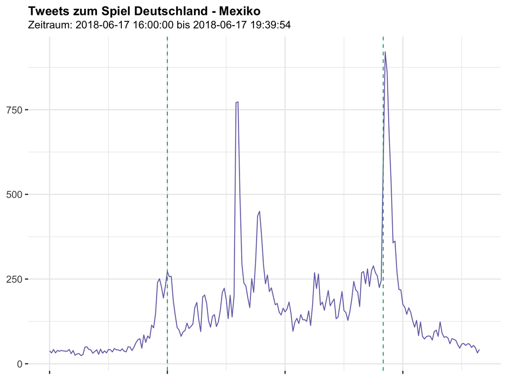

```r
rt %>%
  ts_plot("1 minute",
        color = Mycol[3]) +
  geom_vline(xintercept = gamestart, color=Mycol[1], linetype = 2) +
  geom_vline(xintercept = gameend, color=Mycol[1], linetype = 2) +
  theme(plot.title = element_text(face = "bold"),
        axis.text.x = element_blank()) +
  labs(
    x = NULL, y = NULL,
    title = "Tweets zum Spiel Deutschland - Mexiko",
    subtitle = paste("Zeitraum:",min(rt$created_at),"bis",max(rt$created_at))
  )
```

## Retweets

Welche Tweets wurden am häufigsten geteilt? Die top 10 sind:

```r
rt %>%
  filter(is_retweet == FALSE ) %>%
  dplyr::select(screen_name, text, retweet_count) %>%
  group_by(screen_name, text) %>%
  summarise(retweet_count = sum(retweet_count)) %>%
  arrange(desc(retweet_count)) %>%
  .[1:10,] %>%
  #knitr::kable(align = "l")
  htmlTable::htmlTable(align="l")
```

|  | screen_name | text | retweet_count |
| --- | --- | --- | --- |
| 1 | DFB_Team | Schluss! #DieMannschaft verliert den WM-Auftakt gegen Mexiko. #GERMEX 0-1 #ZSMMN https://t.co/wE73FNLBrv | 1356 |
| 2 | ThatRexGuy | Joachim Löw when literally anything happens. #GERMEX #WorldCup https://t.co/5e0xQ9Q3Yy | 1172 |
| 3 | KuehniKev | Sportminister ist in #Deutschland übrigens Horst Seehofer. 🤷🏼‍♂️ #GERMEX | 906 |
| 4 | DerWachsame | Wir haben ein Fußballspiel verloren, das ist traurig, aber nicht schlimm. Morgen wird vielleicht ein durchgeknallter Innenminister im Alleingang die Grenzen schließen und die Regierung sprengen. DAS i… | 801 |
| 5 | ghensel | Mal im Ernst. Rausfliegen in der Vorrunde passt doch bombe zu unserer masochistischen Gefühlslage gerade. Ich sehe schon die Talkshow-Themen vor mir: „Deutsches WM-Aus. Welche Rolle spielt der Islam?“… | 499 |
| 6 | DFB_Team | Seid ihr bereit für #GERMEX 🇩🇪🇲🇽? #ZSMMN #WM2018 #GERMEX https://t.co/POxvqBKDBj | 491 |
| 7 | DFB_Team | Auf geht’s, Männer!!! 🇩🇪🇲🇽 #ZSMMN #WM2018 #GERMEX 0-0 https://t.co/l13goZrece | 470 |
| 8 | DFB_Team | Halbzeit. Mund abputzen. Da geht noch was, Männer! #GERMEX 0-1 #DieMannschaft #ZSMMN https://t.co/0ZJu1R64iL | 443 |
| 9 | OomenBerlin | Seit wir Nazis im Bundestag haben hat die #Nationalmannschaft noch kein WM-Spiel gewonnen. Denkt mal drüber nach. #GERMEX #WM2018 | 440 |
| 10 | FCBayern | 🇩🇪 Kopf hoch, Männer! #WeiterImmerWeiter #GERMEX #DieMannschaft #WM2018 https://t.co/CLHAah2jJo | 431 |

## Wordcloud

```r
rt_clean <- rt %>%
  # First, remove http elements manually
  mutate(stripped_text = gsub(http,"", text)) %>%
  mutate(stripped_text = gsub("germex","", text, ignore.case = T))

rt_tidy_words <- rt_clean %>%
  # Second, remove punctuation, convert to lowercase, add id for each tweet!
  dplyr::select(stripped_text) %>%
  unnest_tokens(word, stripped_text) %>%

  # Third, remove stop words from your list of words
  anti_join(stopwords) %>%

  # Count Word occurences in a tweet
  count(word, sort = TRUE)

rt_tidy_words %>%
  wordcloud2(size = 3,
           color = "random-light", backgroundColor = "grey")
```

[interactive chart not shown]

#### Wie sind die Wörter miteinander verlinkt?

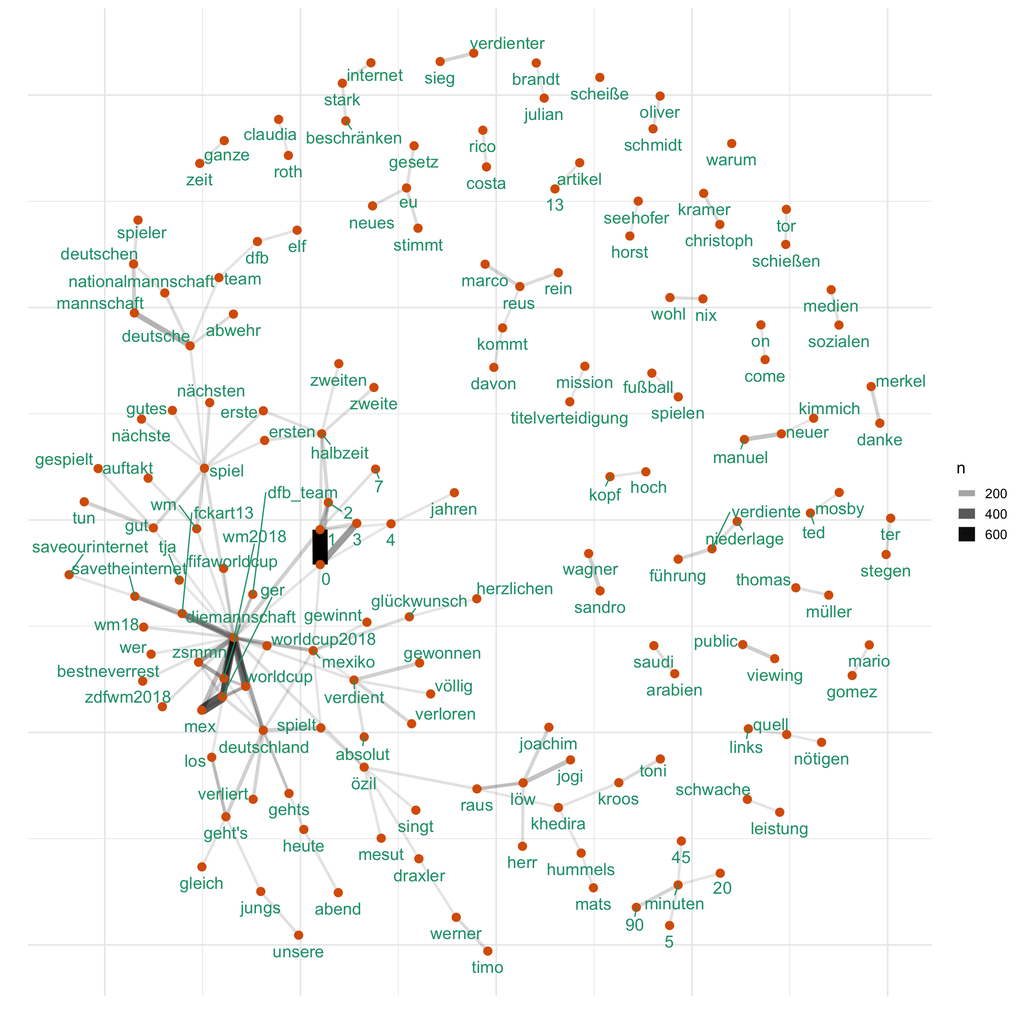

```r
word_network(rt_clean)
```

# Sentiment Analyse

```r
sent <- c(
  # positive Wörter
  readLines("../../dict/SentiWS_v1.8c_Negative.txt",
            encoding = "UTF-8"),
  # negative Wörter
  readLines("../../dict/SentiWS_v1.8c_Positive.txt",
            encoding = "UTF-8")
) %>% lapply(function(x) {
  # Extrahieren der einzelnen Spalten
  res <- strsplit(x, "\t", fixed = TRUE)[[1]]
  return(data.frame(words = res[1], value = res[2],
                    stringsAsFactors = FALSE))
}) %>%
  bind_rows %>%
  mutate(word = gsub("\\|.*", "", words) %>% tolower,
         value = as.numeric(value)) %>%
  # manche Wörter kommen doppelt vor, hier nehmen wir den mittleren Wert
  group_by(word) %>% summarise(value = mean(value)) %>% ungroup
```

```r
sentDF <- rt_clean %>%
  # Second, remove punctuation, convert to lowercase, add id for each tweet!
  unnest_tokens(word, stripped_text) %>%
  left_join(., sent, by="word") %>%
  mutate(value = as.numeric(value)) %>%
  #filter(!is.na(value)) %>%
  mutate(negative = ifelse(value < 0, value, NA),
         positive = ifelse(value > 0, value, NA),
         negative_d = ifelse(value < 0, 1, 0),
         positive_d = ifelse(value > 0, 1, 0))
```

### Wordclouds

#### Positive Wörter

```r
sentDF %>%
  filter(positive_d == 1) %>%
  count(word) %>%
  wordcloud2(color = "random-light", backgroundColor = "grey")
```

[interactive chart not shown]

#### Negative wörter

```r
sentDF %>%
  filter(negative_d == 1) %>%
  count(word) %>%
  wordcloud2(color = "random-light", backgroundColor = "grey")
```

[interactive chart not shown]

#### Top 10 positive Tweets

```r
sentDF.grouped <- sentDF %>%
  group_by(status_id) %>%
  summarise(mean_value = mean(value, na.rm = T),
            sum_value = sum(value, na.rm = T),
            positive = sum(positive, na.rm = T),
            negative = sum(negative, na.rm = T)) %>%
  left_join(., rt %>% dplyr::select(status_id, screen_name, text, created_at),
            by = "status_id") %>%
  filter(!is.na(mean_value))

sentDF.grouped %>%
  arrange(desc(mean_value)) %>%
  select(screen_name, text, mean_value, created_at) %>%
  .[1:10,] %>%
  htmlTable::htmlTable(align="l")
```

|  | screen_name | text | mean_value | created_at |
| --- | --- | --- | --- | --- |
| 1 | Hessenfriese | @BILD Ist uns fast gelungen….. #GERMEX #WM2018 https://t.co/quDq0wTnMX | 1 | 2018-06-17 17:01:12 |
| 2 | Mastermind_09 | Draxler und Reus bislang ungefähr mit gleich vielen gelungen Ballaktionen. #GERMEX | 1 | 2018-06-17 17:22:02 |
| 3 | GmachtZumTxtn | Noch nie ist es einer Mannschaft gelungen seinen eigenen Linksverteidiger so aus dem Spiel zu nehmen #GERMEX | 1 | 2018-06-17 18:37:26 |
| 4 | nerdfromaustria | Der Sonntag wäre perfekt, wenn Deutschland eins auf die Nase kriegt… Ganz neutral gesprochen ;) #GERMEX #WM2018 | 0.7299 | 2018-06-17 16:12:47 |
| 5 | DerFilmer | That feel wenn der @BR24 Radiokommentar perfekt synchron zum @BBCSport Fernsehbild ist. #GERMEX #WM2018 | 0.7299 | 2018-06-17 17:11:25 |
| 6 | mir70 | Kimmich passt vom Sympathiefaktor perfekt zum FC Bayern … #GERMEX | 0.7299 | 2018-06-17 17:26:16 |
| 7 | nerow1909 | @Endi_AJ Wer gerade mal seinen lamborghini ausfahren will, kann das gerade perfekt tun. Auch in der kölner innenstadt. #germex | 0.7299 | 2018-06-17 17:31:51 |
| 8 | Sarpei007 | Naja. Die Taktik von Mex ist halt perfekt gegen die immergleiche Aufstellung/Taktik von uns. #GERMEX | 0.7299 | 2018-06-17 17:46:21 |
| 9 | allo_morph | Ich nutze auch perfekt die Räume. Im Schlafzimmer schlafe ich, im Wohnzimmer wohne ich, im Badezimmer dusche ich…och Menno! #GERMEX | 0.7299 | 2018-06-17 17:54:25 |
| 10 | hassanscorner | Man muss aber auch sagen, dass der Testspielgegner Saudi-Arabien die Mexikaner perfekt simuliert hat. #GERMEX | 0.7299 | 2018-06-17 17:54:43 |

#### Top 10 negative Tweets

```r
sentDF.grouped %>%
  arrange(mean_value) %>%
  select(screen_name, text, mean_value, created_at) %>%
  .[1:10,] %>%
  htmlTable::htmlTable(align="l")
```

mean_value

created_at

1

DieMone37

Neuer wird nicht in die Gefahr kommen einzuschlafen. #WM2018 #GERMEX

-1

2018-06-17 17:02:47

2

hyouhakuhunter

Deine Meinungsfreiheit ist in Gefahr!

@fckart13 #FCKArt13 #GERMEX #WM2018 https://t.co/h8XhRv1Adu

-1

2018-06-17 17:04:02

3

sirxwastaken

Das Internet ist in Gefahr und ihr habt nur Augen für einen Ball.

Schaut wenigstens in der Halbzeit mal vorbei und informiert euch!

https://t.co/QujMbEK3E1

#GERMEX #fckart13 #WM2018 #ger #mex #DieMannschaft

-1

2018-06-17 17:04:22

4

sportwetten_de

8. Min., 0:0: Aber auch Mexikos Freistöße sind eher eine Bewerbung für Fieldgoals beim Football als eine Gefahr für Manuel Neuer. #swde #GERMEX #liveticker #WM2018

-1

2018-06-17 17:10:31

5

Baumbart4Z0

Das freie Internet ist in Gefahr! #WM2018 #FCKArt13 #GERMEX https://t.co/lmKRfYI6bK

-1

2018-06-17 17:13:00

6

anjaSeeBR

Am 20/21.06 stimmt das EUparlament über Artikel 13 ab. Memes, Videos, Remixe, Parodien, Zitate sind in Gefahr #Meinungsfreiheit

Informier dich: https://t.co/KhlVEENOXh

#GERMEX #WM2018 #savetheinternet #FCKArt13 #SaveOurInternet

-1

2018-06-17 17:20:59

7

Winkendekatze

SCHAUT NICHT WEG! Das Internet ist in Gefahr!